# Unit 4: Basic Coding

Depends. Sometimes we figure out how to merge it. Sometimes we don’t. Depends on the project.

**What if there aren’t exact string matches?**

You can either use fuzzy matching (fast but not terribly accurate) or prayer to your favorite divine/earthly entity. Basically, its a BIG problem everyone has and there’s no good solution.

I come across this problem often enough I wrote a wrapper for this sort of thing. This one uses the [Jaro-Winkler Distance](https://en.wikipedia.org/wiki/Jaro%E2%80%93Winkler_distance).

```r
these_packages_for_string_matching <- c("pbmcapply","stringdist","magrittr")

to_install <- c(these_packages_for_string_matching %in% rownames(installed.packages()) == FALSE)

install.packages(setdiff(to_install, rownames(installed.packages())),repos = "http://cran.us.r-project.org")

library(dplyr)
library(pbmcapply)
library(stringdist)
library(magrittr)

#inputs: two data frames target_df and new_df.  outputs, dataframe with matches
fuzzyMatch <- function (a, b) {

  # calculate a jaccard dissimilarity matrix
  distance <- stringdistmatrix(a,b,method = 'jw', p = 0.1, useBytes = T)

  # find the closest match for each
  match <- apply(distance, 1, which.min)

  # find how far away these were
  dists <- apply(distance, 1, min)

  # return these as a two-column matrix
  return (cbind(match = match,
                distance = dists))

}

apply_fuzzy_match <- function(df_a, col_in_a, df_b, col_in_b, max.dist){

  # df_a = Unmatched_Titles
  # col_in_a = "Match_Name"
  # df_b = unique_titles_in_raw_coding
  # col_in_b = "Match_Name"
  # max.dist = 0.2

  df_a_var <- c(col_in_a)
  df_b_var <- c(col_in_b)

  df_a_column <- df_a %>% dplyr::select(dplyr::all_of(df_a_var)) %>% pull()
  df_b_column <- df_b %>% dplyr::select(dplyr::all_of(df_b_var)) %>% pull()

  #apply matching algorithm
  matches <- pbmclapply(X = df_a_column, FUN = function(X, b) fuzzyMatch(X,b), b=df_b_column)
  indx <- sapply(matches, length)
  match_df <- as.data.frame(do.call(rbind,lapply(matches, `length<-`,max(indx))))

  #update the data frame
  a_frame <- df_a %>%
    dplyr::select(dplyr::all_of(df_a_var))

  b_frame <- df_b %>%
    dplyr::select(dplyr::all_of(df_b_var)) %>%
    slice(match_df[,"match"]) %>%
    dplyr::bind_cols(match_df[,"match"]) %>%
    rename("Match_Row_In_B" = 2) %>%
    dplyr::bind_cols(match_df[,"distance"]) %>%
    rename("JW_Distance" = 3)

  a_frame %<>%
    dplyr::bind_cols(b_frame) %>%
    filter(JW_Distance <= max.dist )

  names(a_frame) <- c(
    c(paste0("A_",col_in_a)), c(paste0("B_",col_in_b)), "Row_Match_From_DF_B", "JW_Distance"
  )

  return(a_frame)
}

example_a <- tibble(
  org = c("Goldman Sachs Inc","bank of america", "Steve's Madeup Company"),
  some_x_var = c(3, 5, 8),
)

example_b <- tibble(
  org1 = c("Goldman Sachs ","bank of america NA", "Another unrelated company"),
  some__other_x_var = c(3, 5, 2),
)

apply_fuzzy_match(df_a = example_a, col_in_a = "org", df_b = example_b, col_in_b = "org1",max.dist = 0.1)
```

```
## # A tibble: 2 × 4
##   A_org             B_org1               Row_Match_From_DF_B JW_Distance
##   <chr>             <chr>                              <dbl>       <dbl>
## 1 Goldman Sachs Inc "Goldman Sachs "                       1      0.0353
## 2 bank of america   "bank of america NA"                   2      0.0333
```

# 7 Loops and Functions

You’ll likely need to create functions and loops to analyze/parse data.

Here is the structure of a basic for loop. We loop over the numbers 32 to 100, and, for each element of the loop apply the formula to convert Fahrenheit into Celsius.

```r
loop_over_this <- 32:100 # you can experiment with any numeric range

# making C a blank list here
C <- list()

for(i in loop_over_this){
  # What are you looping over
  print(i)
  # If we pretend that the i's are degrees Fahrenheit and we want to convert them into Celsius we can do the following
  C[i] <- (i - 32) * 5/9
  print(C[i])
}
```

```
## [1] 32
## [[1]]
## [1] 0
##
## [1] 33
## [[1]]
## [1] 0.5555556
##
## [1] 34
## [[1]]
## [1] 1.111111
##
## [1] 35
## [[1]]
## [1] 1.666667
##
## [1] 36
## [[1]]
## [1] 2.222222
##
## [1] 37
## [[1]]
## [1] 2.777778
##
## [1] 38
## [[1]]
## [1] 3.333333
##
## [1] 39
## [[1]]
## [1] 3.888889
##
## [1] 40
## [[1]]
## [1] 4.444444
##
## [1] 41
## [[1]]
## [1] 5
##
```

[output cut: 220 more lines]

```
## [1] 97
## [[1]]
## [1] 36.11111
##
## [1] 98
## [[1]]
## [1] 36.66667
##
## [1] 99
## [[1]]
## [1] 37.22222
##
## [1] 100
## [[1]]
## [1] 37.77778
```

```r
tibble(Fahrenheit = loop_over_this,
       Celsius = unlist(C))
```

```
## # A tibble: 69 × 2
##    Fahrenheit Celsius
##         <int>   <dbl>
##  1         32   0
##  2         33   0.556
##  3         34   1.11
##  4         35   1.67
##  5         36   2.22
##  6         37   2.78
##  7         38   3.33
##  8         39   3.89
##  9         40   4.44
## 10         41   5
## # … with 59 more rows
```

We can also do this as a function.

```r
F_to_C_Converter <- function(Fahrenheit){
  C = (Fahrenheit - 32) * 5/9
  return(C)
}

F_to_C_Converter(77)
```

```
## [1] 25
```

```r
F_to_C_Converter(1:100)
```

```
##   [1] -17.2222222 -16.6666667 -16.1111111 -15.5555556 -15.0000000 -14.4444444
##   [7] -13.8888889 -13.3333333 -12.7777778 -12.2222222 -11.6666667 -11.1111111
##  [13] -10.5555556 -10.0000000  -9.4444444  -8.8888889  -8.3333333  -7.7777778
##  [19]  -7.2222222  -6.6666667  -6.1111111  -5.5555556  -5.0000000  -4.4444444
##  [25]  -3.8888889  -3.3333333  -2.7777778  -2.2222222  -1.6666667  -1.1111111
##  [31]  -0.5555556   0.0000000   0.5555556   1.1111111   1.6666667   2.2222222
##  [37]   2.7777778   3.3333333   3.8888889   4.4444444   5.0000000   5.5555556
##  [43]   6.1111111   6.6666667   7.2222222   7.7777778   8.3333333   8.8888889
##  [49]   9.4444444  10.0000000  10.5555556  11.1111111  11.6666667  12.2222222
##  [55]  12.7777778  13.3333333  13.8888889  14.4444444  15.0000000  15.5555556
##  [61]  16.1111111  16.6666667  17.2222222  17.7777778  18.3333333  18.8888889
##  [67]  19.4444444  20.0000000  20.5555556  21.1111111  21.6666667  22.2222222
##  [73]  22.7777778  23.3333333  23.8888889  24.4444444  25.0000000  25.5555556
##  [79]  26.1111111  26.6666667  27.2222222  27.7777778  28.3333333  28.8888889
##  [85]  29.4444444  30.0000000  30.5555556  31.1111111  31.6666667  32.2222222
##  [91]  32.7777778  33.3333333  33.8888889  34.4444444  35.0000000  35.5555556
##  [97]  36.1111111  36.6666667  37.2222222  37.7777778
```

# 8 Summary Statistics

Once you have data you need to describe it so both you and your audience know what it is. Below are some useful summary statistics.

Why are they useful? You want to see how messy your data is.

n is the number of observations. We care about this because we want to know how much data we’re dealing with. If some variables have more information than others, this helps us figure out where the variables are missing.

mean/median are good too.

min/max are good for looking for outliers. One definition of outlier is the third quantile (75th percentile) + 3 times the range from the 25-75th quantiles (for low outliers replace 3rd with first and the plus with a minus)

quantiles give you a sense of how the data is distributed. There are no hard and fast rules about good (or ‘bad’) distributions of data but, you should look out for things that are strange.

standard deviation is a measure of how a variable is spread. The formula is $\sigma = \sqrt{\sum{(x_i-\mu)^2}/n}$. If your data is all the same number, the standard deviation will be 0 (and you should find new data).

Note the pipe **%>%** that connects the data object mtcars to to the command that changes the data **summarize**

Dplyr makes summarizing across one variable moderatly easy.

```r
mtcars %>%
  summarise(
            n = n(),
            min = min(mpg),
            Q1 = quantile(mpg, 0.25, na.rm = T),
            median = quantile(mpg, 0.5, na.rm = T),
            Q3 = fivenum(mpg)[4],
            Q75 = quantile(mpg, 0.75, na.rm = T),
            Q99 = quantile(mpg, 0.99, na.rm = T),
            max = max(mpg),
            sd = sd(mpg)) %>%
  #' This stuff below just makes the data above display nicely for you, its completely unnecessary for most uses.
  kable(digits = 2) %>%
  kable_styling(bootstrap_options = c("striped", "hover"))  %>%
  scroll_box(width = "900px", height = "200px")
```

| n | min | Q1 | median | Q3 | Q75 | Q99 | max | sd |
| --- | --- | --- | --- | --- | --- | --- | --- | --- |
| 32 | 10.4 | 15.43 | 19.2 | 22.8 | 22.8 | 33.44 | 33.9 | 6.03 |

Suppose, however, you wanted to summarize across multiple variables. dplyr makes this a pain. The psych library, however, makes it a little easier. Just use the following code. The key here is that data.frame() allows us to keep the variable names. Without it, we wouldn’t have names for the variables.

```r
storms %>%
  select_if(is.numeric) %>%
  psych::describe(quant = c(0.25, 0.75, 0.90), check=TRUE) %>%
  data.frame() %>%
  rownames_to_column(var = "name") %>%
  tibble() %>%
  select(name, n, min, Q0.25, median, mean, Q0.75, max, se) %>%
  mutate(across(where(is.numeric), round, 1))
```

```
## # A tibble: 10 × 9
##    name                        n    min  Q0.25 median   mean  Q0.75    max    se
##    <chr>                   <dbl>  <dbl>  <dbl>  <dbl>  <dbl>  <dbl>  <dbl> <dbl>
##  1 year                    11859 1975   1992   2002   2001.  2011   2020     0.1
##  2 month                   11859    1      8      9      8.8    9     12     0
##  3 day                     11859    1      8     16     15.8   24     31     0.1
##  4 hour                    11859    0      6     12      9.1   18     23     0.1
##  5 lat                     11859    7.2   17.5   24.6   24.8   31.3   51.9   0.1
##  6 long                    11859 -109.   -80.7  -64.4  -64.1  -48.4   -6     0.2
##  7 wind                    11859   10     35     45     53.6   65    160     0.2
##  8 pressure                11859  882    985    999    992   1006   1022     0.2
##  9 tropicalstorm_force_di…  5350    0     60    120    145.   210    870     1.7
## 10 hurricane_force_diamet…  5350    0      0      0     18.1   25    300     0.5
```

Skim is a great package for summarizing variables - unless you need a variable they don’t have. Then good luck. See https://cran.r-project.org/web/packages/skimr/vignettes/extending_skimr.html

```r
library(skimr)
storms %>%
  skimr::skim() %>%
  knitr::kable() %>%
  kableExtra::kable_styling(
    bootstrap_options = "striped", # several design options
    full_width = FALSE, # defaults to TRUE
    position = "center", # where is it positioned?
    fixed_thead = TRUE # whether header is fixed when scrolling through -- only for longer tables
  ) %>%
  kableExtra::column_spec(1, bold = TRUE, border_right = TRUE) # column specifications can be easily modified
```

| skim_type | skim_variable | n_missing | complete_rate | character.min | character.max | character.empty | character.n_unique | character.whitespace | factor.ordered | factor.n_unique | factor.top_counts | numeric.mean | numeric.sd | numeric.p0 | numeric.p25 | numeric.p50 | numeric.p75 | numeric.p100 | numeric.hist |
| --- | --- | --- | --- | --- | --- | --- | --- | --- | --- | --- | --- | --- | --- | --- | --- | --- | --- | --- | --- |
| character | name | 0 | 1.0000000 | 3 | 9 | 0 | 214 | 0 | NA | NA | NA | NA | NA | NA | NA | NA | NA | NA | NA |
| character | status | 0 | 1.0000000 | 9 | 19 | 0 | 3 | 0 | NA | NA | NA | NA | NA | NA | NA | NA | NA | NA | NA |
| factor | category | 0 | 1.0000000 | NA | NA | NA | NA | NA | TRUE | 7 | 0: 5347, -1: 2898, 1: 1934, 2: 749 | NA | NA | NA | NA | NA | NA | NA | NA |
| numeric | year | 0 | 1.0000000 | NA | NA | NA | NA | NA | NA | NA | NA | 2001.282317 | 12.000987 | 1975.0 | 1992.0 | 2002.0 | 2011.0 | 2020.0 | ▃▅▇▇▇ |
| numeric | month | 0 | 1.0000000 | NA | NA | NA | NA | NA | NA | NA | NA | 8.784805 | 1.261106 | 1.0 | 8.0 | 9.0 | 9.0 | 12.0 | ▁▁▂▇▃ |
| numeric | day | 0 | 1.0000000 | NA | NA | NA | NA | NA | NA | NA | NA | 15.832617 | 8.943993 | 1.0 | 8.0 | 16.0 | 24.0 | 31.0 | ▇▆▆▆▆ |
| numeric | hour | 0 | 1.0000000 | NA | NA | NA | NA | NA | NA | NA | NA | 9.116789 | 6.725162 | 0.0 | 6.0 | 12.0 | 18.0 | 23.0 | ▇▇▇▇▁ |
| numeric | lat | 0 | 1.0000000 | NA | NA | NA | NA | NA | NA | NA | NA | 24.758040 | 8.514218 | 7.2 | 17.5 | 24.6 | 31.3 | 51.9 | ▅▇▇▃▁ |
| numeric | long | 0 | 1.0000000 | NA | NA | NA | NA | NA | NA | NA | NA | -64.089316 | 19.737395 | -109.3 | -80.7 | -64.4 | -48.4 | -6.0 | ▃▇▇▅▁ |
| numeric | wind | 0 | 1.0000000 | NA | NA | NA | NA | NA | NA | NA | NA | 53.637743 | 26.189074 | 10.0 | 35.0 | 45.0 | 65.0 | 160.0 | ▇▇▂▁▁ |
| numeric | pressure | 0 | 1.0000000 | NA | NA | NA | NA | NA | NA | NA | NA | 991.980521 | 19.548269 | 882.0 | 985.0 | 999.0 | 1006.0 | 1022.0 | ▁▁▁▃▇ |
| numeric | tropicalstorm_force_diameter | 6509 | 0.4511342 | NA | NA | NA | NA | NA | NA | NA | NA | 145.253271 | 126.093780 | 0.0 | 60.0 | 120.0 | 210.0 | 870.0 | ▇▃▁▁▁ |
| numeric | hurricane_force_diameter | 6509 | 0.4511342 | NA | NA | NA | NA | NA | NA | NA | NA | 18.147664 | 35.539912 | 0.0 | 0.0 | 0.0 | 25.0 | 300.0 | ▇▁▁▁▁ |

**Beware**

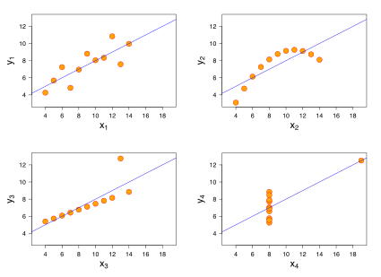

Anscombe’s quartet

From https://en.wikipedia.org/wiki/Anscombe%27s_quartet

The following has the same mean, median, and variance even though they are from very different data generating processes.

## 8.1 Summarizing by group

Sometimes you want to summarize data by group. dplyr makes this easy with the group_by() function.

Below, using the nycflights13 - all flights in and out of NYC in 2013 - data, let’s walk through a few basic data summarization tasks.

First, let’s get tallies of manufacturers.

```r
nycflights13::planes %>%
  group_by(manufacturer) %>%
  tally() %>%
  arrange(desc(n))
```

```
## # A tibble: 35 × 2
##    manufacturer                      n
##    <chr>                         <int>
##  1 BOEING                         1630
##  2 AIRBUS INDUSTRIE                400
##  3 BOMBARDIER INC                  368
##  4 AIRBUS                          336
##  5 EMBRAER                         299
##  6 MCDONNELL DOUGLAS               120
##  7 MCDONNELL DOUGLAS AIRCRAFT CO   103
##  8 MCDONNELL DOUGLAS CORPORATION    14
##  9 CANADAIR                          9
## 10 CESSNA                            9
## # … with 25 more rows
```

Next, we may want to get average seats by manufacturer. Instead of using tally(), we’re going to use n() which does the same thing except preserves the rest of the data.

```r
nycflights13::planes %>%
  group_by(manufacturer) %>%
  summarize(
    n = n(),
    mean_seats = mean(seats),
    median_seats = median(seats),
    sd_seats = sd(seats)
  ) %>%
  arrange(desc(n))
```

```
## # A tibble: 35 × 5
##    manufacturer                      n mean_seats median_seats sd_seats
##    <chr>                         <int>      <dbl>        <dbl>    <dbl>
##  1 BOEING                         1630     175.            149     59.5
##  2 AIRBUS INDUSTRIE                400     187.            182     23.9
##  3 BOMBARDIER INC                  368      74.0            80     17.8
##  4 AIRBUS                          336     221.            200     81.4
##  5 EMBRAER                         299      45.6            55     15.5
##  6 MCDONNELL DOUGLAS               120     162.            172     14.4
##  7 MCDONNELL DOUGLAS AIRCRAFT CO   103     142             142      0
##  8 MCDONNELL DOUGLAS CORPORATION    14     142             142      0
##  9 CANADAIR                          9      55              55      0
## 10 CESSNA                            9       5.33            6      2
## # … with 25 more rows
```

You can summarize variables by group too. The following example summarizes departure delays and distance flown by airline.

```r
nycflights13::flights %>%
  group_by(carrier) %>%
  dplyr::select(dep_delay, distance) %>%
  skimr::skim()
```

Table 8.1: Data summary

| Name | Piped data |
| --- | --- |
| Number of rows | 336776 |
| Number of columns | 3 |
| _______________________ |  |
| Column type frequency: |  |
| numeric | 2 |
| ________________________ |  |
| Group variables | carrier |

**Variable type: numeric**

| skim_variable | carrier | n_missing | complete_rate | mean | sd | p0 | p25 | p50 | p75 | p100 | hist |
| --- | --- | --- | --- | --- | --- | --- | --- | --- | --- | --- | --- |
| dep_delay | 9E | 1044 | 0.94 | 16.73 | 45.91 | -24 | -6 | -2.0 | 17 | 747 | ▇▁▁▁▁ |
| dep_delay | AA | 636 | 0.98 | 8.59 | 37.35 | -24 | -6 | -3.0 | 4 | 1014 | ▇▁▁▁▁ |
| dep_delay | AS | 2 | 1.00 | 5.80 | 31.36 | -21 | -7 | -3.0 | 3 | 225 | ▇▁▁▁▁ |
| dep_delay | B6 | 466 | 0.99 | 13.02 | 38.50 | -43 | -5 | -1.0 | 12 | 502 | ▇▁▁▁▁ |
| dep_delay | DL | 349 | 0.99 | 9.26 | 39.74 | -33 | -5 | -2.0 | 5 | 960 | ▇▁▁▁▁ |
| dep_delay | EV | 2817 | 0.95 | 19.96 | 46.55 | -32 | -5 | -1.0 | 25 | 548 | ▇▁▁▁▁ |
| dep_delay | F9 | 3 | 1.00 | 20.22 | 58.36 | -27 | -4 | 0.5 | 18 | 853 | ▇▁▁▁▁ |
| dep_delay | FL | 73 | 0.98 | 18.73 | 52.66 | -22 | -4 | 1.0 | 17 | 602 | ▇▁▁▁▁ |
| dep_delay | HA | 0 | 1.00 | 4.90 | 74.11 | -16 | -7 | -4.0 | -1 | 1301 | ▇▁▁▁▁ |
| dep_delay | MQ | 1234 | 0.95 | 10.55 | 39.18 | -26 | -7 | -3.0 | 9 | 1137 | ▇▁▁▁▁ |
| dep_delay | OO | 3 | 0.91 | 12.59 | 43.07 | -14 | -9 | -6.0 | 4 | 154 | ▇▁▁▁▁ |
| dep_delay | UA | 686 | 0.99 | 12.11 | 35.72 | -20 | -4 | 0.0 | 11 | 483 | ▇▁▁▁▁ |
| dep_delay | US | 663 | 0.97 | 3.78 | 28.06 | -19 | -7 | -4.0 | 0 | 500 | ▇▁▁▁▁ |
| dep_delay | VX | 31 | 0.99 | 12.87 | 44.82 | -20 | -4 | 0.0 | 8 | 653 | ▇▁▁▁▁ |
| dep_delay | WN | 192 | 0.98 | 17.71 | 43.34 | -13 | -2 | 1.0 | 17 | 471 | ▇▁▁▁▁ |
| dep_delay | YV | 56 | 0.91 | 19.00 | 49.17 | -16 | -7 | -2.0 | 23 | 387 | ▇▁▁▁▁ |
| distance | 9E | 0 | 1.00 | 530.24 | 321.80 | 94 | 228 | 509.0 | 740 | 1587 | ▇▆▂▂▁ |
| distance | AA | 0 | 1.00 | 1340.24 | 637.74 | 187 | 888 | 1096.0 | 1521 | 2586 | ▁▇▅▁▃ |
| distance | AS | 0 | 1.00 | 2402.00 | 0.00 | 2402 | 2402 | 2402.0 | 2402 | 2402 | ▁▁▇▁▁ |
| distance | B6 | 0 | 1.00 | 1068.62 | 703.71 | 173 | 340 | 1023.0 | 1428 | 2586 | ▆▇▂▁▂ |
| distance | DL | 0 | 1.00 | 1236.90 | 660.17 | 94 | 762 | 1020.0 | 1598 | 2586 | ▂▇▁▂▃ |
| distance | EV | 0 | 1.00 | 562.99 | 287.49 | 80 | 284 | 533.0 | 748 | 1389 | ▇▇▆▃▁ |
| distance | F9 | 0 | 1.00 | 1620.00 | 0.00 | 1620 | 1620 | 1620.0 | 1620 | 1620 | ▁▁▇▁▁ |
| distance | FL | 0 | 1.00 | 664.83 | 160.89 | 397 | 397 | 762.0 | 762 | 762 | ▃▁▁▁▇ |
| distance | HA | 0 | 1.00 | 4983.00 | 0.00 | 4983 | 4983 | 4983.0 | 4983 | 4983 | ▁▁▇▁▁ |
| distance | MQ | 0 | 1.00 | 569.53 | 226.23 | 184 | 431 | 502.0 | 762 | 1147 | ▂▇▂▃▂ |
| distance | OO | 0 | 1.00 | 500.81 | 206.17 | 229 | 419 | 419.0 | 419 | 1008 | ▁▇▁▁▁ |
| distance | UA | 0 | 1.00 | 1529.11 | 798.80 | 116 | 937 | 1400.0 | 2425 | 4963 | ▇▅▆▁▁ |
| distance | US | 0 | 1.00 | 553.46 | 583.82 | 17 | 214 | 529.0 | 544 | 2153 | ▇▇▁▁▂ |
| distance | VX | 0 | 1.00 | 2499.48 | 88.05 | 2248 | 2475 | 2475.0 | 2586 | 2586 | ▁▁▁▇▇ |
| distance | WN | 0 | 1.00 | 996.27 | 410.43 | 169 | 725 | 748.0 | 1411 | 2133 | ▁▇▁▃▁ |
| distance | YV | 0 | 1.00 | 375.03 | 159.72 | 96 | 229 | 229.0 | 544 | 544 | ▁▇▁▁▇ |

But this is a bit messy, and we may want to see the airlines actual names.

```r
nycflights13::flights %>%
  dplyr::select(carrier, dep_delay, distance) %>%
  # Here I'm
  left_join(nycflights13::airlines, by = "carrier") %>%
  dplyr::select(-carrier) %>%
  group_by(name) %>%
  skimr::skim() %>%
  arrange(name) %>%
  # These options just make the data look nice in RMarkdown
  kable(caption = "Example for a table with some descriptives") %>%
  kable_styling(
    bootstrap_options = "striped", # several design options
    full_width = FALSE, # defaults to TRUE
    position = "center", # where is it positioned?
    fixed_thead = TRUE # whether header is fixed when scrolling through -- only for longer tables
  ) %>%
  column_spec(1, bold = TRUE, border_right = TRUE) %>% # column specifications can be easily modified
  footnote(general = "You can add some footnotes with certain signs, too.", # this is how you add a footnote
           number = c("Footnote 1; ", "Footnote 2; "),
           alphabet = c("Footnote A; ", "Footnote B; "),
           symbol = c("Footnote Symbol 1; ", "Footnote Symbol 2"),
           general_title = "General: ", number_title = "Type I: ",
           alphabet_title = "Type II: ", symbol_title = "Type III: ",
           footnote_as_chunk = T, title_format = c("italic", "underline")
           )
```

Table 8.2: Example for a table with some descriptives

| skim_type | skim_variable | name | n_missing | complete_rate | numeric.mean | numeric.sd | numeric.p0 | numeric.p25 | numeric.p50 | numeric.p75 | numeric.p100 | numeric.hist |
| --- | --- | --- | --- | --- | --- | --- | --- | --- | --- | --- | --- | --- |
| numeric | dep_delay | AirTran Airways Corporation | 73 | 0.9776074 | 18.726075 | 52.66160 | -22 | -4 | 1.0 | 17 | 602 | ▇▁▁▁▁ |
| numeric | distance | AirTran Airways Corporation | 0 | 1.0000000 | 664.829448 | 160.88804 | 397 | 397 | 762.0 | 762 | 762 | ▃▁▁▁▇ |
| numeric | dep_delay | Alaska Airlines Inc. | 2 | 0.9971989 | 5.804775 | 31.36303 | -21 | -7 | -3.0 | 3 | 225 | ▇▁▁▁▁ |
| numeric | distance | Alaska Airlines Inc. | 0 | 1.0000000 | 2402.000000 | 0.00000 | 2402 | 2402 | 2402.0 | 2402 | 2402 | ▁▁▇▁▁ |
| numeric | dep_delay | American Airlines Inc. | 636 | 0.9805677 | 8.586016 | 37.35486 | -24 | -6 | -3.0 | 4 | 1014 | ▇▁▁▁▁ |
| numeric | distance | American Airlines Inc. | 0 | 1.0000000 | 1340.235999 | 637.73615 | 187 | 888 | 1096.0 | 1521 | 2586 | ▁▇▅▁▃ |
| numeric | dep_delay | Delta Air Lines Inc. | 349 | 0.9927458 | 9.264504 | 39.73505 | -33 | -5 | -2.0 | 5 | 960 | ▇▁▁▁▁ |
| numeric | distance | Delta Air Lines Inc. | 0 | 1.0000000 | 1236.901206 | 660.17241 | 94 | 762 | 1020.0 | 1598 | 2586 | ▂▇▁▂▃ |
| numeric | dep_delay | Endeavor Air Inc. | 1044 | 0.9434453 | 16.725769 | 45.90604 | -24 | -6 | -2.0 | 17 | 747 | ▇▁▁▁▁ |
| numeric | distance | Endeavor Air Inc. | 0 | 1.0000000 | 530.235753 | 321.79871 | 94 | 228 | 509.0 | 740 | 1587 | ▇▆▂▂▁ |
| numeric | dep_delay | Envoy Air | 1234 | 0.9532523 | 10.552041 | 39.18457 | -26 | -7 | -3.0 | 9 | 1137 | ▇▁▁▁▁ |
| numeric | distance | Envoy Air | 0 | 1.0000000 | 569.532712 | 226.22871 | 184 | 431 | 502.0 | 762 | 1147 | ▂▇▂▃▂ |
| numeric | dep_delay | ExpressJet Airlines Inc. | 2817 | 0.9479999 | 19.955390 | 46.55235 | -32 | -5 | -1.0 | 25 | 548 | ▇▁▁▁▁ |
| numeric | distance | ExpressJet Airlines Inc. | 0 | 1.0000000 | 562.991730 | 287.48816 | 80 | 284 | 533.0 | 748 | 1389 | ▇▇▆▃▁ |
| numeric | dep_delay | Frontier Airlines Inc. | 3 | 0.9956204 | 20.215543 | 58.36265 | -27 | -4 | 0.5 | 18 | 853 | ▇▁▁▁▁ |
| numeric | distance | Frontier Airlines Inc. | 0 | 1.0000000 | 1620.000000 | 0.00000 | 1620 | 1620 | 1620.0 | 1620 | 1620 | ▁▁▇▁▁ |
| numeric | dep_delay | Hawaiian Airlines Inc. | 0 | 1.0000000 | 4.900585 | 74.10990 | -16 | -7 | -4.0 | -1 | 1301 | ▇▁▁▁▁ |
| numeric | distance | Hawaiian Airlines Inc. | 0 | 1.0000000 | 4983.000000 | 0.00000 | 4983 | 4983 | 4983.0 | 4983 | 4983 | ▁▁▇▁▁ |
| numeric | dep_delay | JetBlue Airways | 466 | 0.9914707 | 13.022522 | 38.50337 | -43 | -5 | -1.0 | 12 | 502 | ▇▁▁▁▁ |
| numeric | distance | JetBlue Airways | 0 | 1.0000000 | 1068.621525 | 703.70566 | 173 | 340 | 1023.0 | 1428 | 2586 | ▆▇▂▁▂ |
| numeric | dep_delay | Mesa Airlines Inc. | 56 | 0.9068220 | 18.996330 | 49.17227 | -16 | -7 | -2.0 | 23 | 387 | ▇▁▁▁▁ |
| numeric | distance | Mesa Airlines Inc. | 0 | 1.0000000 | 375.033278 | 159.71957 | 96 | 229 | 229.0 | 544 | 544 | ▁▇▁▁▇ |
| numeric | dep_delay | SkyWest Airlines Inc. | 3 | 0.9062500 | 12.586207 | 43.06599 | -14 | -9 | -6.0 | 4 | 154 | ▇▁▁▁▁ |
| numeric | distance | SkyWest Airlines Inc. | 0 | 1.0000000 | 500.812500 | 206.17225 | 229 | 419 | 419.0 | 419 | 1008 | ▁▇▁▁▁ |
| numeric | dep_delay | Southwest Airlines Co. | 192 | 0.9843585 | 17.711744 | 43.34435 | -13 | -2 | 1.0 | 17 | 471 | ▇▁▁▁▁ |
| numeric | distance | Southwest Airlines Co. | 0 | 1.0000000 | 996.269083 | 410.42961 | 169 | 725 | 748.0 | 1411 | 2133 | ▁▇▁▃▁ |
| numeric | dep_delay | United Air Lines Inc. | 686 | 0.9883065 | 12.106073 | 35.71660 | -20 | -4 | 0.0 | 11 | 483 | ▇▁▁▁▁ |
| numeric | distance | United Air Lines Inc. | 0 | 1.0000000 | 1529.114873 | 798.80468 | 116 | 937 | 1400.0 | 2425 | 4963 | ▇▅▆▁▁ |
| numeric | dep_delay | US Airways Inc. | 663 | 0.9677152 | 3.782418 | 28.05633 | -19 | -7 | -4.0 | 0 | 500 | ▇▁▁▁▁ |
| numeric | distance | US Airways Inc. | 0 | 1.0000000 | 553.456272 | 583.82252 | 17 | 214 | 529.0 | 544 | 2153 | ▇▇▁▁▂ |
| numeric | dep_delay | Virgin America | 31 | 0.9939946 | 12.869421 | 44.81510 | -20 | -4 | 0.0 | 8 | 653 | ▇▁▁▁▁ |
| numeric | distance | Virgin America | 0 | 1.0000000 | 2499.482178 | 88.04889 | 2248 | 2475 | 2475.0 | 2586 | 2586 | ▁▁▁▇▇ |

General: You can add some footnotes with certain signs, too.  
Type I: <sup>1</sup> Footnote 1; <sup>2</sup> Footnote 2;  
Type II: <sup>a</sup> Footnote A; <sup>b</sup> Footnote B;  
Type III: * Footnote Symbol 1; † Footnote Symbol 2

## 8.2 Exercise

Take a data set, figure out how the variables are stored, and give me the median, mean, standard deviation, 75th and 95th percentile of hlth. hlth is the processed version of health. To see the difference between the two, just swap them out in the exercise below and you’ll notice a difference.

Download the data from http://www.masteringmetrics.com/wp-content/uploads/2021/04/Data.zip. Load it using haven::read_dta(“INSERT FILE PATH HERE”)

## 8.3 Exercise: Answer

```r
NHIS <- haven::read_dta("Data/NHIS2009_clean.dta")

# see if data is numeric or not.  If not, will need to convert
lapply(X = NHIS, FUN = class)
```

```
## $year
## [1] "numeric"
##
## $inc1
## [1] "numeric"
##
## $inc2
## [1] "numeric"
##
## $inc3
## [1] "numeric"
##
## $inc4
## [1] "numeric"
##
## $inc5
## [1] "numeric"
##
## $inc6
## [1] "numeric"
##
## $inc7
## [1] "numeric"
##
## $inc8
## [1] "numeric"
##
## $serial
## [1] "numeric"
##
## $hhweight
## [1] "numeric"
##
## $pernum
## [1] "numeric"
##
## $perweight
## [1] "numeric"
##
## $sampweight
```

[output cut: 64 more lines]

```
##
## $brooks
## [1] "numeric"
##
## $marradult
## [1] "numeric"
##
## $marradult_empl
## [1] "numeric"
##
## $adltempl
## [1] "numeric"
##
## $hi_hsb1
## [1] "numeric"
```

```r
NHIS %>%
  tibble() %>%
  select(hlth, educ) %>%
  psych::describe(quant = c(0.75, 0.95), check=TRUE) %>%
  data.frame() %>%
  rownames_to_column(var = "name") %>%
  tibble() %>%
  select(name, n, median, mean, sd, Q0.75, Q0.95) %>%
  mutate(across(where(is.numeric), round, 1))
```

```
## # A tibble: 2 × 7
##   name      n median  mean    sd Q0.75 Q0.95
##   <chr> <dbl>  <dbl> <dbl> <dbl> <dbl> <dbl>
## 1 hlth  80634      4   3.9   1.1     5     5
## 2 educ  80634     14  12.3   6.2    17    20
```

# 9 Plotting

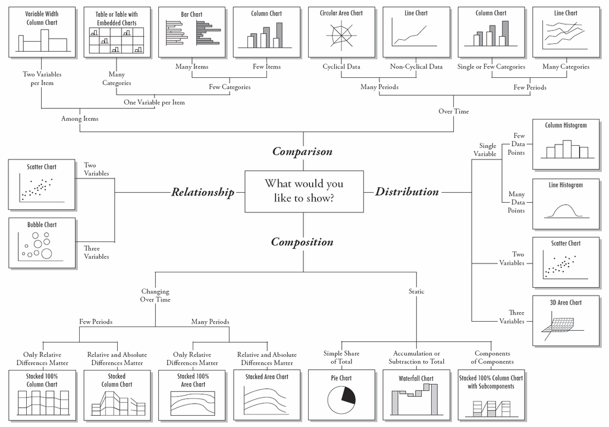

Types of Plots Stolen Shamelessly From https://judgelord.github.io/PS811/6-data-viz.html

Before you plot, figure out why you’re doing it. In general we plot:

1 - To figure out what our data looks like

2 - To explain our findings/data to others

Know which one you’re doing first! If it’s 1, don’t waste an hour getting everything exactly right. Just look for weirdness in the data that you want to investigate. If it’s 2, then make sure the plot looks good and is presentable to others.

In R you can do both with ggplot2 and a couple of standard commands. This section will be grossly incomplete given there are books devoted to the subject.

The best way to show how to use ggplot is to work through an example. Suppose we want to plot the hour-by-hour weather at JFK for a year.

There are way too many themes to review here but you can change the themes as much as you want. See e.g., https://ggplot2-book.org/polishing.html and https://towardsdatascience.com/themes-to-spice-up-visualizations-with-ggplot2-3e275038dafa. Keep in mind that (a) if you’re not printing in color you should use some black/white/grey theme like theme_bw().

As a sidenote: since your goal in plotting is to make the data accessible to others, you should consider using themes that are accessible to those who are color blind. This is not a small population! See e.g., https://www.sciencedirect.com/science/article/pii/S2352304215000215

**NOTE: INSIDE GGPLOT THE PIPE (%>%) WILL CAUSE AN ERROR, USE A + SIGN**

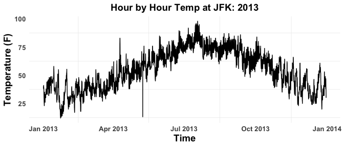

```r
if(c("ggthemes") %!in% installed.packages()){install.packages('ggthemes')}

library(ggthemes)

# Load Data (this one is easy because it's built into R)
nycflights13::weather %>%
  # Filter out EWR and LGA
  filter(origin == "JFK") %>%
  # start plotting commands
  ggplot(aes(x = time_hour, y = temp)) +
  # make it a line plot
  geom_line() +
  # minimal theme
  theme_minimal() +
  #scale_y_continuous(label = scales::comma) +
  xlab("Time") + ylab("Temperature (F)") +
  ggtitle("Hour by Hour Temp at JFK: 2013") +
  theme(
    # Make title front and center size 14 font
    plot.title = element_text(size=14, face="bold",hjust = 0.5),
    axis.title.x = element_text(size=14, face="bold"),
    axis.title.y = element_text(size=14, face="bold"),
    strip.text.x = element_text(size=10, face="bold"),
    axis.text = element_text(size=10, face="bold"),
    # axis.text.x = element_blank(),
    #panel.border = element_blank(),
    panel.grid.major = element_blank(),
    #panel.grid.minor = element_blank(),
    legend.position = "none"
  )
```

Above there looks like there’s some weirdness at JFK

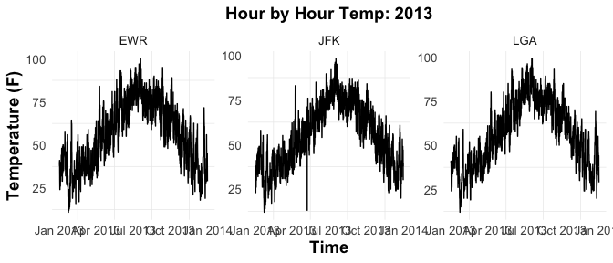

```r
nycflights13::weather %>%
  # start plotting commands
  ggplot(aes(x = time_hour, y = temp)) +
  # make it a line plot
  geom_line() +
  # minimal theme
  theme_minimal() +
  facet_wrap(~ origin, scales = "free") +
  #scale_y_continuous(label = scales::comma) +
  xlab("Time") + ylab("Temperature (F)") +
  ggtitle("Hour by Hour Temp: 2013") +
  theme(
    # Make title front and center
    plot.title = element_text(size=14, face="bold",hjust = 0.5),
    axis.title.x = element_text(size=14, face="bold"),
    axis.title.y = element_text(size=14, face="bold"),
    strip.text.x = element_text(size=10),
    axis.text = element_text(size=10),
    # axis.text.x = element_blank(),
    #panel.border = element_blank(),
    panel.grid.major = element_blank(),
    #panel.grid.minor = element_blank(),
    legend.position = "none"
  )
```

In the above example, the x-axis labels overlap, so you want to adjust them.

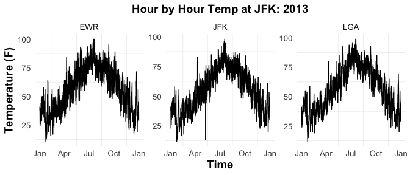

```r
nycflights13::weather %>%
  # start plotting commands
  ggplot(aes(x = time_hour, y = temp)) +
  # make it a line plot
  geom_line() +
  # minimal theme
  theme_minimal() +
  scale_x_datetime(date_labels = "%b") +
  facet_wrap(~ origin, scales = "free") +
  #scale_y_continuous(label = scales::comma) +
  xlab("Time") + ylab("Temperature (F)") +
  ggtitle("Hour by Hour Temp at JFK: 2013") +
  theme(
    # Make title front and center
    plot.title = element_text(size=14, face="bold",hjust = 0.5),
    axis.title.x = element_text(size=14, face="bold"),
    axis.title.y = element_text(size=14, face="bold"),
    strip.text.x = element_text(size=10),
    axis.text = element_text(size=10),
    # axis.text.x = element_blank(),
    #panel.border = element_blank(),
    panel.grid.major = element_blank(),
    #panel.grid.minor = element_blank(),
    legend.position = "none"
  )
```

The scale_x_datetime(date_labels = “%b”) option cleaned up the labels.

We can also plot everything together

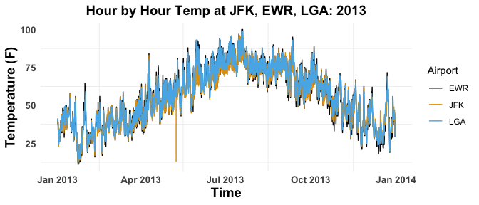

```r
# Now in same plot
nycflights13::weather %>%
  # start plotting commands
  ggplot(aes(x = time_hour, y = temp, col = origin)) +
  # make it a line plot
  geom_line() +
  # minimal theme
  theme_minimal() +
  #scale_y_continuous(label = scales::comma) +
  xlab("Time") + ylab("Temperature (F)") +
  ggtitle("Hour by Hour Temp at JFK, EWR, LGA: 2013") +
  # Alter colors, needs to be same length as col
  #scale_color_manual("Airport",values=c('red','darkblue','darkgreen')) +
  scale_colour_colorblind("Airport") +
  theme(
    # Make title front and center
    plot.title = element_text(size=14, face="bold",hjust = 0.5),
    axis.title.x = element_text(size=14, face="bold"),
    axis.title.y = element_text(size=14, face="bold"),
    strip.text.x = element_text(size=10, face="bold"),
    axis.text = element_text(size=10, face="bold"),
    # axis.text.x = element_blank(),
    #panel.border = element_blank(),
    panel.grid.major = element_blank(),
    #panel.grid.minor = element_blank(),
    #legend.position = "none"
  )
```

The above plot isn’t particularly useful, it’s way too jumbled. So we can just plot the min and max temp per day at LGA.

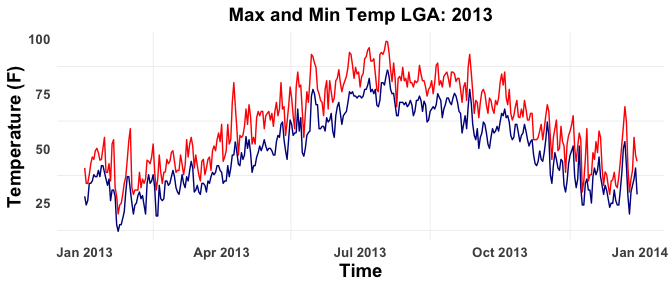

```r
# Now do max and min temperature by day for a year at LGA
nycflights13::weather %>%
  filter(origin == "LGA") %>%
  group_by(year, month, day) %>%
  summarise(
    max.day = max(temp),
    min.day = min(temp)
  ) %>%
  mutate(
    date = lubridate::as_date(c(paste0(year,"-", month, "-", day)))
  ) %>% ungroup() %>%
  ggplot(aes(x = date)) +
  # make it a line plot
  geom_line(aes(y = max.day, col = "red")) +
  geom_line(aes(y = min.day, col = "blue")) +
  # minimal theme
  theme_minimal() +
  #scale_y_continuous(label = scales::comma) +
  xlab("Time") + ylab("Temperature (F)") +
  ggtitle("Max and Min Temp LGA: 2013") +
  # Alter colors, needs to be same length as col
  scale_color_manual("Airport",values=c('darkblue','red')) +
  theme(
    # Make title front and center
    plot.title = element_text(size=14, face="bold",hjust = 0.5),
    axis.title.x = element_text(size=14, face="bold"),
    axis.title.y = element_text(size=14, face="bold"),
    strip.text.x = element_text(size=10, face="bold"),
    axis.text = element_text(size=10, face="bold"),
    # axis.text.x = element_blank(),
    #panel.border = element_blank(),
    panel.grid.major = element_blank(),
    #panel.grid.minor = element_blank(),
    legend.position = "none"
  )
```

Now we may want to do this by month

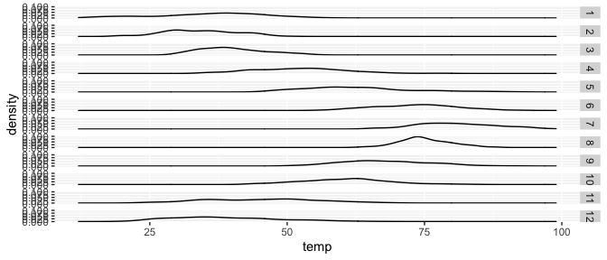

```r
# Now do max and min temperature by day for a year at LGA
nycflights13::weather %>%
  filter(origin == "LGA") %>%
  mutate(
    date = lubridate::as_date(c(paste0(year,"-", month, "-", day)))
  ) %>%
  ggplot(aes(x = temp)) +
  geom_density() +
  facet_grid(month ~ .)
```

The above isn’t particularly useful, but with some easy modifications we can make it much more useful and beautiful.

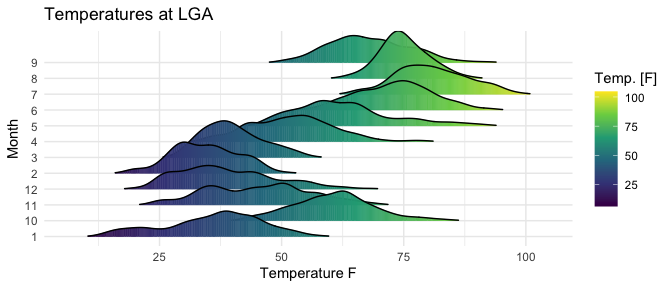

```r
# Can also use one of the million add-ons to ggplot2
if("ggridges" %!in% installed.packages()){install.packages('ggridges')}

library(ggridges)
nycflights13::weather %>%
  filter(origin == "LGA") %>%
  ggplot( aes(x = temp, y = as.character(month), fill = ..x..) ) +
  geom_density_ridges_gradient(scale = 3, rel_min_height = 0.01) +
  scale_fill_viridis_c() +
  labs(title = "Temperatures at LGA", fill = "Temp. [F]") +
  xlab("Temperature F") +
  ylab("Month") +
  theme_minimal()
```

What gives here? Note that the y axis is out of order - this happens sometimes when numbers are converted to characters.

How did I solve this issue? I googled “order months in ggplot axis” and clicked on https://stackoverflow.com/questions/36020146/how-can-i-order-the-months-chronologically-in-ggplot2-short-of-writing-the-month. When I did that I noticed that December was on top and January was on the bottom. So I googled “ggridges reverse order” and clicked on https://community.rstudio.com/t/reverse-order-of-categorical-y-axis-in-ggridges-ggplot2/2273 and found that I could do y = fct_rev(month).

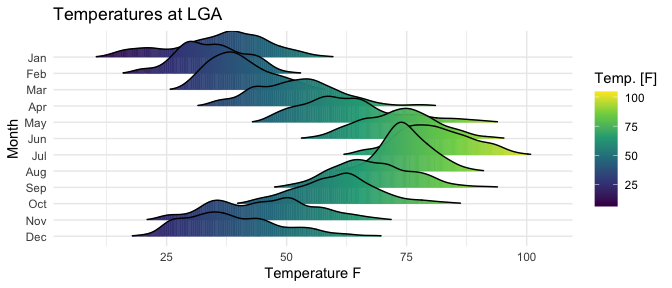

```r
library(ggridges)
nycflights13::weather %>%
  filter(origin == "LGA") %>%
  mutate(
  month = factor(month.abb[month], levels = month.abb)
  ) %>%
  ggplot( aes(x = temp, y =  fct_rev(month), fill = ..x..) ) +
  geom_density_ridges_gradient(scale = 3, rel_min_height = 0.01) +
  scale_fill_viridis_c() +
  labs(title = "Temperatures at LGA", fill = "Temp. [F]") +
  xlab("Temperature F") +
  ylab("Month") +
  theme_minimal()
```

**Searching for weirdness in your data**

When you get a dataset, you often want to do some sort of histogram/scatterplot/something as a check on your data. While basic summaries like skim() are good for some outliers, you want to make sure there aren’t weird groups of observations together that you should spend some time looking into.

In assembling this guide, I looked at the weather data and noticed something strange.

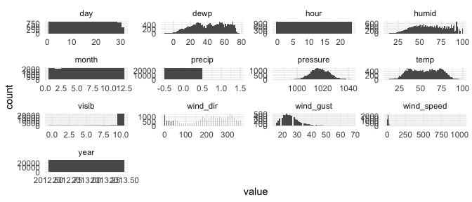

```r
nycflights13::weather %>%
  keep(is.numeric) %>%                     # Keep only numeric columns
  gather("variable", "value") %>%
  ggplot(aes(value)) +
  facet_wrap(~ variable, scales = "free") +
  geom_histogram(binwidth = 1) +
  theme_minimal()
```

The right tail on wind speed looks suspicious as does the left tail on pressure. Let’s check them out with skim.

```r
library(skimr)

nycflights13::weather %>%
  dplyr::select(pressure, wind_speed) %>%
  skim()
```

Table 9.1: Data summary

| Name | Piped data |
| --- | --- |
| Number of rows | 26115 |
| Number of columns | 2 |
| _______________________ |  |
| Column type frequency: |  |
| numeric | 2 |
| ________________________ |  |
| Group variables | None |

**Variable type: numeric**

| skim_variable | n_missing | complete_rate | mean | sd | p0 | p25 | p50 | p75 | p100 | hist |
| --- | --- | --- | --- | --- | --- | --- | --- | --- | --- | --- |
| pressure | 2729 | 0.9 | 1017.90 | 7.42 | 983.8 | 1012.9 | 1017.60 | 1023.00 | 1042.10 | ▁▁▇▆▁ |
| wind_speed | 4 | 1.0 | 10.52 | 8.54 | 0.0 | 6.9 | 10.36 | 13.81 | 1048.36 | ▇▁▁▁▁ |

Note the 1048 mile an hour gust. This is an error. So, we should remove it from the data.

```r
nyc_weather_2013 <- nycflights13::weather %>%
  filter(wind_speed < 200)
```

What about the low pressure? 984 mb is low, but not unheard of in NYC. We should see something strange happening that day like lots of wind or rain.

```r
nyc_weather_2013 %>%
  filter(pressure < 990)
```

```
## # A tibble: 7 × 15
##   origin  year month   day  hour  temp  dewp humid wind_dir wind_speed wind_gust
##   <chr>  <int> <int> <int> <int> <dbl> <dbl> <dbl>    <dbl>      <dbl>     <dbl>
## 1 EWR     2013     1    31     2  62.1  57.9  86.3      180       31.1      47.2
## 2 EWR     2013     1    31     3  62.1  59    89.7      180       27.6      44.9
## 3 JFK     2013     1    31     2  50    50   100        180       27.6      38.0
## 4 JFK     2013     1    31     6  52.0  48.9  89.3      200       28.8      34.5
## 5 LGA     2013     1    31     1  57.0  54.0  89.5      170       19.6      33.4
## 6 LGA     2013     1    31     5  57.9  52.0  80.6      200       13.8      21.9
## 7 LGA     2013     1    31     6  57.0  50    77.3      220       23.0      35.7
## # … with 4 more variables: precip <dbl>, pressure <dbl>, visib <dbl>,
## #   time_hour <dttm>
```

That looks ok. The low reading seems consistent with a nasty storm moving across the NYC area.

You can also do density plots. This time you can check on the wind speed to see if there are any 199 mph gusts that should be investigated.

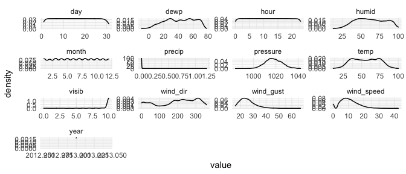

```r
nyc_weather_2013 %>%
  keep(is.numeric) %>%                     # Keep only numeric columns
  gather("variable", "value") %>%
  ggplot(aes(value)) +
  facet_wrap(~ variable, scales = "free") +  # In separate panels
  geom_density()  +# as density
  theme_minimal()
```

## 9.1 Maps

You can make maps with R too. This example is stolen from https://datavizpyr.com/how-to-make-world-map-with-ggplot2-in-r/

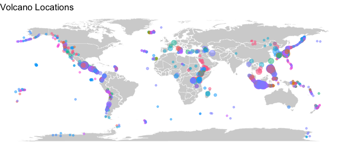

```r
# note that we can read CSVs from a website
volcano <- readr::read_csv("https://raw.githubusercontent.com/rfordatascience/tidytuesday/master/data/2020/2020-05-12/volcano.csv")

# load a world map
world <- map_data("world")

ggplot() +
  geom_map(
    # load the data and the map itelf
    data = world, map = world,
    # this tells ggplot2 how to make countries.  without region you don't have countries like Aruba
    aes(long, lat, map_id = region),
    color = "white", fill = "lightgray", size = 0.1
  ) +
  # plot the volcano data in points
  geom_point(
    data = volcano,
    aes(longitude, latitude,
        color = primary_volcano_type,
        size=population_within_100_km),
    alpha = 0.5
  ) +
  theme_void() +
  theme(legend.position = "none")+
  labs(title="Volcano Locations")
```

# 10 Regression

Josh Angrist (as in Nobel Lauriate Josh Angrist) writes: “I like to define the regression of $Y_i$ on a vector of covariates, $X_i$, as the best linear predictor (BLP) of $Y_i$ given $X_i$. This regression origin story gives no quarter to the question of why we’re running it. (http://www.masteringmetrics.com/wp-content/uploads/2020/07/lny20n06MRU_R3-1.pdf)”

In other words, linear regression models the linear relationship between a dependent variable and one or more independent variables. A dependent variable is what you want to explain. Independent variables explain the dependent variable. Linear regression allows us to quantify a relationship between a dependent and independent variable while controlling for other factors. For example, they can tell us the impact of attending a private school on earnings while controlling for things like parental income, race, and being an athlete (see Mastering Metrics, page 63).

One important concept above is that regression is the best **linear** predictor. The data may not be linear. If it isn’t, a standard technique is to try to make it more linear by transforming the predictors (e.g., logging them).

Think of regression as a fancy way of drawing a line (with one predictor), a plane (with 2), or a hyperplane (with n predictors).

For example, the formula for a regression with two independent variables is the following:

$${Y_i} = {\alpha} + {\beta}X_{1i} + {\gamma X_{2i}} + \epsilon_i$$

Regression assigns values to model parameters $\alpha$,$\beta$,and$\gamma$ to make the estimated $\hat{Y_i}$ as close as possible to the actual data - the $Y_i$. A computer can do this relatively quickly.

For n regressors - a more typical application - we use the shorthand:
$${Y} = X{\beta} + \epsilon$$

Think of this like the following:

[$y_1$=1 $x_{11}$ … $x_1k$] [${\beta_0}$]+[$\epsilon_1$]

[$y_2$=1 $x_{21}$ … $x_2k$] [${\beta_1}$]+[$\epsilon_2$]

…

[$y_2$=1 $x_{n1}$ … $x_nk$] [${\beta_n}$]+[$\epsilon_n$]

OLS is the ordinary (as in all elements are treated equally) least squares estimate of the parameter $\beta$ that minimizes $\epsilon'$$\epsilon$. To save you a lot of time, the result is that $\hat{\beta} = (X'X)^{-1}X'Y$.

We should dwell on the “ordinary” part for a second - this means that outliers can really screw with our results as an outlier is treated the same as any other observation. Maybe this is ok for your particular project, maybe it isn’t.

**A Few Notes About Regressions**

You’ll probably have to learn something about the properties of regression. You can do that in almost any textbook. See e.g., http://assets.press.princeton.edu/chapters/s6946.pdf

**Garbage in Garbage out**

If your data is bad*, no amount of fancy (or non-fancy) regressions can save it.

*This includes, but is not limited to having a lot of missing values, mis-measured variables, being a strange sample, etc…

**Is my regression causal?**

Likely not. This is too technical a discussion for this brief guide.

**Correlation is Not Causation**

Nick Cage movies and drownings are highly correlated. So are the divorce rate in Maine and US margarine consumption. Murders by steam, vapor and hot objects and the age of Miss America are also correlated. See, e.g., http://www.tylervigen.com/spurious-correlations.

What does this mean? It means that the mechanics of regression work *whether or not the output makes sense.* So it’s up to you to tell us why you did the analysis.

## 10.1 Interpreting Regression Coefficients

See https://stats.idre.ucla.edu/other/mult-pkg/faq/general/faqhow-do-i-interpret-a-regression-model-when-some-variables-are-log-transformed/ for a fuller guide.

A regression coefficient tells us how changing the independent variable x by one unit changes the dependent variable y. The constant is the baseline value of y given to all the x’s. It may not make any sense. While we may sometimes be interested in the constant, we’re almost always interested in doing a hypothesis test to see if the independent variable has a statistically significant effect on the dependent variable (i.e. the null hypothesis is that ${\beta}=0$ and the alternative hypothesis is that ${\beta}\neq0$).

Using ordinary least squares, this list gives you a guide for interpreting regression coefficients:

- No logged dependent (DVs) or independent variables (IVs) (e.g., ${y_i}={\alpha}+{\beta}x_i$)
  - A one unit increase in the IV results in a _ increase in the DV
  - A slightly more sophisticated way of doing it is a one standard deviation increase in the IV results in a _ increase in the DV
- A logged dependent variable, unlogged independent variable (e.g., ${ln(y_i)}={\alpha}+{\beta}x_i$)
  - Interpret as a percentage in the following way: Take the ${\beta}$ and make it the exponent of e. So $e^{{\beta}} = ?$. You can do this in R with the command “exp(${\beta}$)”. Suppose $e^{{\beta}} = 1.12$ then you can say that a one unit increase in the IV increases the DV by 12%
- Unlogged DV, logged IV (e.g., ${y_i}={\alpha}+{\beta}ln(x_i)$)
  - Interpreted as an x (in this example 10) percent increase in the independent variable increases the dependent variable by _ units. Units measured as the DV is measured.
  - $e^{1.1}*\beta$ - A 10% increase in IV increases DV by _ units
- Logged DV & IV (e.g., ${ln(y_i)}={\alpha}+{\beta}ln(x_i)$)
  - Interpret as a x% increase in the independent variable increases the dependent variable by _%
  - $1.1^{{\beta}}$

## 10.2 Running Regressions

The code is really easy. It’s lm(y ~ x1 + x2 + x3, data = your_data). Getting the data, interpretation, design, what variables to include, and everything else is definitely not!

Also, if you don’t use the broom package, your output will be messy and difficult to export.

Let’s use the mtcars dataset to demonstrate

```r
lm(formula = mpg ~ hp + wt, data = mtcars)
```

```
##
## Call:
## lm(formula = mpg ~ hp + wt, data = mtcars)
##
## Coefficients:
## (Intercept)           hp           wt
##    37.22727     -0.03177     -3.87783
```

This output … isn’t useful. We have no idea what the standard errors are. And the relationship between the standard errors and the coefficients allows us to say something about the relationship between the independent and dependent variables.

```r
summary(lm(formula = mpg ~ hp + wt, data = mtcars))
```

```
##
## Call:
## lm(formula = mpg ~ hp + wt, data = mtcars)
##
## Residuals:
##    Min     1Q Median     3Q    Max
## -3.941 -1.600 -0.182  1.050  5.854
##
## Coefficients:
##             Estimate Std. Error t value Pr(>|t|)
## (Intercept) 37.22727    1.59879  23.285  < 2e-16 ***
## hp          -0.03177    0.00903  -3.519  0.00145 **
## wt          -3.87783    0.63273  -6.129 1.12e-06 ***
## ---
## Signif. codes:  0 '***' 0.001 '**' 0.01 '*' 0.05 '.' 0.1 ' ' 1
##
## Residual standard error: 2.593 on 29 degrees of freedom
## Multiple R-squared:  0.8268, Adjusted R-squared:  0.8148
## F-statistic: 69.21 on 2 and 29 DF,  p-value: 9.109e-12
```

This is better, but not by much.

```r
library(broom)
lm(formula = mpg ~ hp + wt, data = mtcars) %>%
  tidy(conf.int = TRUE)
```

```
## # A tibble: 3 × 7
##   term        estimate std.error statistic  p.value conf.low conf.high
##   <chr>          <dbl>     <dbl>     <dbl>    <dbl>    <dbl>     <dbl>
## 1 (Intercept)  37.2      1.60        23.3  2.57e-20  34.0      40.5
## 2 hp           -0.0318   0.00903     -3.52 1.45e- 3  -0.0502   -0.0133
## 3 wt           -3.88     0.633       -6.13 1.12e- 6  -5.17     -2.58
```

This is much better! We can do stuff with this output, like plot it.

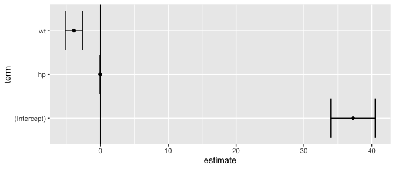

```r
lm(formula = mpg ~ hp + wt, data = mtcars) %>%
  tidy(conf.int = TRUE) %>%
  ggplot( aes(y = term, x = estimate) ) +
  geom_point() +
  geom_errorbarh( aes(xmin = conf.low, xmax = conf.high) ) +
  geom_vline(xintercept = 0) # vertical line at 0
```

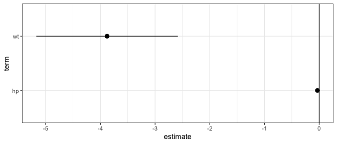

```r
lm(formula = mpg ~ hp + wt, data = mtcars) %>%
  tidy(conf.int = TRUE) %>%
  filter(term != "(Intercept)") %>%
  ggplot( aes(x = term, y = estimate) ) +
  # geom_pointrange() is like geom_point + geom_segment
  geom_pointrange( aes(ymin = conf.low, ymax = conf.high) ) +
  geom_hline(yintercept = 0) + # "horizontal" line at 0
  coord_flip() + # flip x and y axes
  theme_bw() # nicer looking plots
```

Now we may want to check our data to make sure we don’t have any strange outliers that could change our analysis.

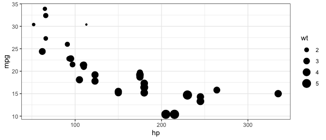

```r
mtcars %>%
  ggplot( aes(x = hp, y = mpg) ) +
  geom_point( aes(size = wt) ) +
  theme_bw() # nicer looking plots
```

# 11 A Worked Through Example

Suppose we care about the relationship between health and health insurance while controlling for age, sex and education. Does having insurance make people healthier? Maybe, because people with health insurance can get preventative care. Or maybe not, because people who choose to buy health insurance may, on average, be less healthy.

So let’s put together what we’ve learned above and run the analysis.

We’re going to use the 2009 NHIS (National Health Information Survey) data.

Step 1: load the data

```r
NHIS <- haven::read_dta("Data/NHIS2009_clean.dta")
```

Step 2: look at it to see if anything is weird

```r
# create new object so that we don't have to reload the data if we screw up
NHIS_subset <- NHIS %>%
  dplyr::select(educ, uninsured, age, hlth, sex)

NHIS_subset %>%
  skim()
```

Table 11.1: Data summary

| Name | Piped data |
| --- | --- |
| Number of rows | 80634 |
| Number of columns | 5 |
| _______________________ |  |
| Column type frequency: |  |
| character | 4 |
| numeric | 1 |
| ________________________ |  |
| Group variables | None |

**Variable type: character**

| skim_variable | n_missing | complete_rate | min | max | empty | n_unique | whitespace |
| --- | --- | --- | --- | --- | --- | --- | --- |
| educ | 0 | 1 | 1 | 2 | 0 | 23 | 0 |
| uninsured | 0 | 1 | 1 | 1 | 0 | 2 | 0 |
| age | 0 | 1 | 1 | 2 | 0 | 86 | 0 |
| sex | 0 | 1 | 1 | 1 | 0 | 2 | 0 |

**Variable type: numeric**

| skim_variable | n_missing | complete_rate | mean | sd | p0 | p25 | p50 | p75 | p100 | hist |
| --- | --- | --- | --- | --- | --- | --- | --- | --- | --- | --- |
| hlth | 0 | 1 | 3.88 | 1.05 | 1 | 3 | 4 | 5 | 5 | ▁▂▆▇▇ |

Step 3: Something was strange! We have education, uninsured, age, and sex being stored as character variables. Also there are 23 different types for the education variable.

```r
NHIS_subset %>%
  group_by(hlth) %>%
  tally()
```

```
## # A tibble: 5 × 2
##    hlth     n
##   <dbl> <int>
## 1     1  1900
## 2     2  6298
## 3     3 19589
## 4     4 24304
## 5     5 28543
```

```r
NHIS_subset %>%
  group_by(educ) %>%
  tally()
```

```
## # A tibble: 23 × 2
##                                    educ     n
##                               <dbl+lbl> <int>
##  1 0 [NIU]                               5995
##  2 1 [Never attended/kindergarten only]  2898
##  3 2 [Grade 1]                           1407
##  4 3 [Grade 2]                           1421
##  5 4 [Grade 3]                           1590
##  6 5 [Grade 4]                           1525
##  7 6 [Grade 5]                           1541
##  8 7 [Grade 6]                           2428
##  9 8 [Grade 7]                           1649
## 10 9 [Grade 8]                           2451
## # … with 13 more rows
```

```r
NHIS_subset %>%
  group_by(uninsured) %>% # 2 is insured, 1 is uninsured
  tally()
```

```
## # A tibble: 2 × 2
##         uninsured     n
##         <dbl+lbl> <int>
## 1 1 [Not covered] 14037
## 2 2 [Covered]     66597
```

```r
NHIS_subset %>%
  group_by(age) %>%
  tally()
```

```
## # A tibble: 86 × 2
##          age     n
##    <dbl+lbl> <int>
##  1     0 [0]  1142
##  2     1 [1]  1221
##  3     2 [2]  1201
##  4     3 [3]  1231
##  5     4 [4]  1200
##  6     5 [5]  1287
##  7     6 [6]  1199
##  8     7 [7]  1261
##  9     8 [8]  1202
## 10     9 [9]  1347
## # … with 76 more rows
```

```r
NHIS_subset %>%
  group_by(sex) %>% # 2 is female 1 is male
  tally()
```

```
## # A tibble: 2 × 2
##          sex     n
##    <dbl+lbl> <int>
## 1 1 [Male]   38997
## 2 2 [Female] 41637
```

Step 4: Let’s change variables to numeric and make the dummy variables actually dummy variables (variables that just have 0 or 1 as an option) summarize again

```r
NHIS_subset <- NHIS_subset %>%
  mutate(
    educ = as.numeric(educ),
    uninsured = uninsured - 1, #recall 1 is female
    sex = sex - 1)

NHIS_subset %>% skim()
```

Table 11.2: Data summary

| Name | Piped data |
| --- | --- |
| Number of rows | 80634 |
| Number of columns | 5 |
| _______________________ |  |
| Column type frequency: |  |
| character | 1 |
| numeric | 4 |
| ________________________ |  |
| Group variables | None |

**Variable type: character**

| skim_variable | n_missing | complete_rate | min | max | empty | n_unique | whitespace |
| --- | --- | --- | --- | --- | --- | --- | --- |
| age | 0 | 1 | 1 | 2 | 0 | 86 | 0 |

**Variable type: numeric**

| skim_variable | n_missing | complete_rate | mean | sd | p0 | p25 | p50 | p75 | p100 | hist |
| --- | --- | --- | --- | --- | --- | --- | --- | --- | --- | --- |
| educ | 0 | 1 | 12.28 | 6.16 | 0 | 8 | 14 | 17 | 22 | ▃▂▃▇▅ |
| uninsured | 0 | 1 | 0.83 | 0.38 | 0 | 1 | 1 | 1 | 1 | ▂▁▁▁▇ |
| hlth | 0 | 1 | 3.88 | 1.05 | 1 | 3 | 4 | 5 | 5 | ▁▂▆▇▇ |
| sex | 0 | 1 | 0.52 | 0.50 | 0 | 0 | 1 | 1 | 1 | ▇▁▁▁▇ |

Step 5: Let’s plot to check the data

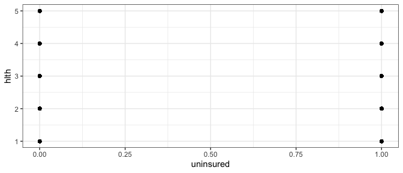

```r
NHIS_subset %>%
  ggplot( aes(x = uninsured, y = hlth) ) +
  geom_point() +
  theme_bw() # nicer looking plots
```

That’s not terribly helpful since both variables are constrained, but useful to make sure that there are no really weird outliers.

Step 6: Run the regression and report the output as a coefficint plot

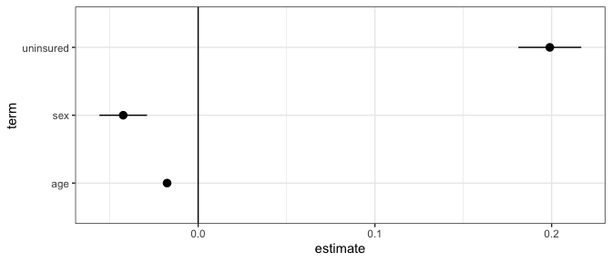

```r
m1 <- lm(data = NHIS_subset,formula = hlth ~ uninsured + age + sex)

m1 %>%
  tidy(conf.int = TRUE) %>%
  filter(term != "(Intercept)") %>%
  ggplot( aes(x = term, y = estimate) ) +
  # geom_pointrange() is like geom_point + geom_segment
  geom_pointrange( aes(ymin = conf.low, ymax = conf.high) ) +
  geom_hline(yintercept = 0) + # "horizontal" line at 0
  coord_flip() + # flip x and y axes
  theme_bw() # nicer looking plots
```

Step 7: check the regression diagnostics

```r
glance(m1)
```

```
## # A tibble: 1 × 12
##   r.squared adj.r.squared sigma statistic p.value    df   logLik     AIC     BIC
##       <dbl>         <dbl> <dbl>     <dbl>   <dbl> <dbl>    <dbl>   <dbl>   <dbl>
## 1     0.141         0.141 0.975     4425.       0     3 -112404. 224817. 224864.
## # … with 3 more variables: deviance <dbl>, df.residual <int>, nobs <int>
```

# 12 Logistic Regression

See https://stats.oarc.ucla.edu/r/dae/logit-regression/

```r
mydata <- read.csv("http://stats.idre.ucla.edu/stat/data/binary.csv")

mylogit <- glm(admit ~ gre + gpa + rank, data = mydata, family = "binomial")

mylogit %>%
  broom::tidy()
```

```
## # A tibble: 4 × 5
##   term        estimate std.error statistic   p.value
##   <chr>          <dbl>     <dbl>     <dbl>     <dbl>
## 1 (Intercept) -3.45      1.13        -3.05 0.00233
## 2 gre          0.00229   0.00109      2.10 0.0356
## 3 gpa          0.777     0.327        2.37 0.0177
## 4 rank        -0.560     0.127       -4.40 0.0000106
```

The interpret ion of these coefficients isn’t straightforward. See https://stats.oarc.ucla.edu/stata/faq/how-do-i-interpret-odds-ratios-in-logistic-regression/

# 13 Text as Data

See https://tutorials.quanteda.io/.

# 14 K-means Clustering

See https://uc-r.github.io/kmeans_clustering

# 15 Links

[0 - Project Home](https://sdr1.github.io/R-Intro-Seminar)

[1 - Installing R and R Studio](https://sdr1.github.io/R-Intro-Seminar/1-r-intro-seminar.html)

[2 - Coding Principles and Debugging](https://sdr1.github.io/R-Intro-Seminar/2-intro-to-coding-debugging.html)

[3 - R Studio Intro](https://sdr1.github.io/R-Intro-Seminar/3-intro-to-r-studio.html)

[4 - Basic Coding](https://sdr1.github.io/R-Intro-Seminar/4-basic-coding.html)

# 16 Appendix

## 16.1 Exercise 1: Answer

```r
> # My version is commented out because I've already installed it
> #install.packages("here")
> library(here)
> here::i_am("4-basic-coding.Rmd")
> getwd()
[1] "/Users/stevenrashin/Documents/GitHub/R-Intro-Seminar"
```

Return to Exercise 1

## 16.2 Appendix II: Problematic p-values

From the American Statistical Association: ``Informally, a p-value is the probability under a specified statistical model that a statistical summary of the data (e.g., the sample mean difference between two compared groups) would be equal to or more extreme than its observed value.” See https://www.tandfonline.com/doi/full/10.1080/00031305.2016.1154108 for more details.

**Why do we use them?**

We use them to see if the statistics we compute (coefficients/means/etc…) are different from 0. In the social sciences we typically use a threshold of 0.05. That means that there is, at most, a 5% chance that the null hypothesis (that there is no effect) cannot be disproved. This is a big deal - a non-significant regression coefficient (i.e. p>0.05) can sink a research paper/dissertation/policy.

**What are some guidelines for interpreting p-values?**

``1) P-values can indicate how incompatible the data are with a specified statistical model.  
2) P-values do not measure the probability that the studied hypothesis is true, or the probability that the data were produced by random chance alone.  
3) Scientific conclusions and business or policy decisions should not be based only on whether a p-value passes a specific threshold.  
4) Proper inference requires full reporting and transparency.  
5) A p-value, or statistical significance, does not measure the size of an effect or the importance of a result.  
6) By itself, a p-value does not provide a good measure of evidence regarding a model or hypothesis (ASA 2016).”

**How do we use them?**

If p<0.05, we can reject the null hypothesis that there is no effect.

**How do we calculate them?**

In general, statistical programs do it for you. See the example below:

```
##
##  Welch Two Sample t-test
##
## data:  a and b
## t = -7.7684, df = 123.65, p-value = 2.619e-12
## alternative hypothesis: true difference in means is not equal to 0
## 95 percent confidence interval:
##  -5.467616 -3.247148
## sample estimates:
## mean of x mean of y
##  5.328477  9.685859
```

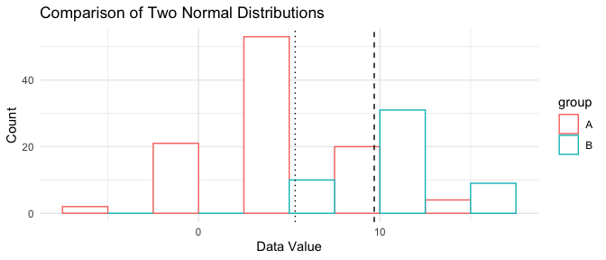

```r
# generate random data
a <- rnorm(n = 100, mean = 5, sd = 4)
b <- rnorm(n = 50, mean = 10, sd = 3)

# now put data into same dataset so that we can easily plot them together
data_together <- tibble(data = c(a,b),
       group = c(rep("A",100),rep("B",50))
       )

ggplot(data_together, aes(x=data, color=group)) +
  geom_histogram(fill="white", position="dodge",binwidth = 5) +
  theme_minimal() +
  geom_vline(xintercept = mean(a), linetype="dotted") +
  geom_vline(xintercept = mean(b), linetype="dashed") +
  ggtitle("Comparison of Two Normal Distributions") +
  xlab("Data Value") + ylab("Count")

t.test(a,b)
```

## 16.3 Appendix III: Why the central limit theorem is cool

Recall that the central limit theorem says that if a sample size is sufficiently large (usually > 30 but no hard guidelines), then the sampling distribution (the distribution of a statistic such as a mean) will be approximately normal.

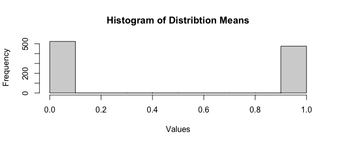

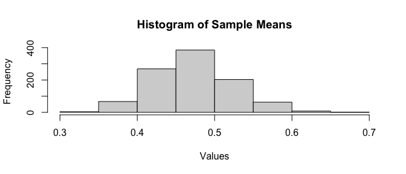

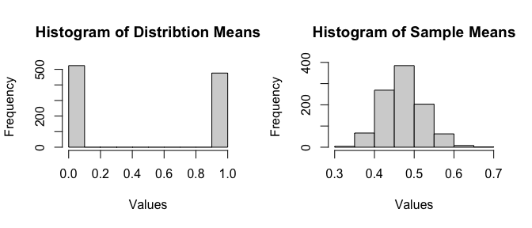

```r
distribution <- as.numeric(rbernoulli(n = 1000,p = 0.5))#rexp(n = 1000,rate = 5)
hist(distribution,main = "Histogram of Distribtion Means",xlab = "Values")
list_of_means <- list()
for(i in 1:1000){
  list_of_means[[i]] <- mean(sample(x = distribution,size = 100,replace = T))
}
hist(unlist(list_of_means),main = "Histogram of Sample Means",xlab = "Values")
par(mfrow=c(1,2))    # set the plotting area into a 1*2 array
hist(distribution,main = "Histogram of Distribtion Means",xlab = "Values")
hist(unlist(list_of_means),main = "Histogram of Sample Means",xlab = "Values")
par(mfrow=c(1,1))    # set the plotting area into a 1*1 array
```

[^1]: This version stolen from https://www.reddit.com/r/ProgrammerHumor/comments/8pdebc/only_god_and_i_knew/ but this is definitely not the original source.
[^2]: See https://faculty.nps.edu/sebuttre/home/R/data.html for more detail
[^3]: I’m not going to define this because it’s immaterial to this point.